# Project Python Foundations: FoodHub Data Analysis

#### What's driving cuisines' relative performance?

This analysis seeks to discover explanations for the unequal number of orders among different cuisine types, since ratings didn't deliver the kind of conclusions needed:

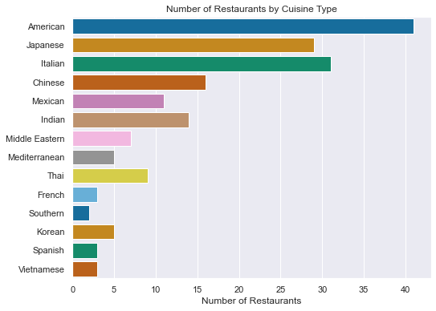

```python
plt.figure(figsize=(8, 6))
sns.barplot(data=agg_ct,
            x = 'rest_n',
            y = 'cuisine',
            palette = 'colorblind')
plt.title('Number of Restaurants by Cuisine Type')
plt.ylabel('')
plt.xlabel('Number of Restaurants')
plt.show()
```

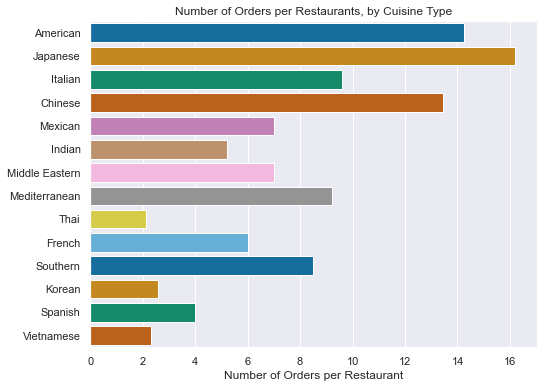

```python
plt.figure(figsize=(8, 6))
sns.barplot(data=agg_ct,
            x = 'ord_per_rest',
            y = 'cuisine',
            palette = 'colorblind')
plt.title('Number of Orders per Restaurants, by Cuisine Type')
plt.ylabel('')
plt.xlabel('Number of Orders per Restaurant')
plt.show()
```

**Some observations:**

The cuisine types with the most quantity of restaurants are American, Japanes and Italian, which explains a lot of their relative presence in terms of order quantities.

While there are much more restaurants serving American food than other types, Japanese restaurants enjoy the highest order per restaurant ratio, followed by American and Chinese restaurants.

Indian restaurants, given their apparently good ratings, could have room for growth.

Thai, Korean, Spanish and Vietnamese restaurants apparently have very low turnovers which merits more research.

More research is needed to determine if there are restaurants with idle capacity that could be used to improve performance.

#### Orders by Cuisine, weekends vs week days:

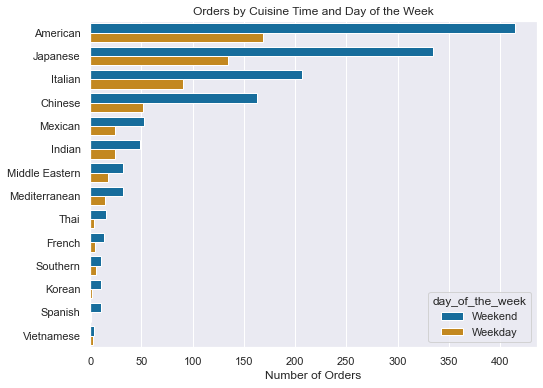

```python
plt.figure(figsize=(8,6))
sns.countplot(data = df,
              hue = 'day_of_the_week',
              y = 'cuisine_type',
              palette = 'colorblind',
              order = df.cuisine_type.value_counts().index)
plt.title('Orders by Cuisine Time and Day of the Week')
plt.ylabel('')
plt.xlabel('Number of Orders')
plt.show()
```

As seen before, the ranking of orders by cuisine type doesn't vary much on weekends vs week days.

### **Question 13:** The company wants to provide a promotional offer in the advertisement of the restaurants. The condition to get the offer is that the restaurants must have a rating count of more than 50 and the average rating should be greater than 4. Find the restaurants fulfilling the criteria to get the promotional offer. [3 marks]

```python
# The approach will be based on the new agg_rest data frame created before
# Crating new columns: ratings count, and ratings average.
rest_lst_ord = agg_rest.loc[:,'restaurant']
agg_rest['rat_count'] = [df[df['restaurant_name'] == rest]['rating_value'].count() for rest in rest_lst_ord]
agg_rest['rat_avg'] = [df[df['restaurant_name'] == rest]['rating_value'].mean() for rest in rest_lst_ord]

# Filtering the desired outcome and ordering by ratings average (descending)
agg_rest[(agg_rest['rat_count'] > 50) & (agg_rest['rat_avg'] > 4)].sort_values(by = 'rat_avg', ascending = False)
```

|  | restaurant | orders | pct | pct_ac | rat_count | rat_avg |
| --- | --- | --- | --- | --- | --- | --- |
| 1 | The Meatball Shop | 132 | 6.95 | 18.49 | 84 | 4.51 |
| 3 | Blue Ribbon Fried Chicken | 96 | 5.06 | 29.82 | 64 | 4.33 |
| 0 | Shake Shack | 219 | 11.54 | 11.54 | 133 | 4.28 |
| 2 | Blue Ribbon Sushi | 119 | 6.27 | 24.76 | 73 | 4.22 |

#### Observations:

The former table lists the 4 restaurants that satisfy both conditions, ordered by descending ratings average: The Meatball Shop, Blue Ribbon Fried Chicken, Shake Shack, and Blue Ribbon Sushi.

These kinds of offers could incentivize restaurants to ask customers for their rating score, improving the quality of the data gathering.

Still, in our opinion the value of the score itself is not very indicative of the quality of the customer experience (about 50% of rated orders get 5 points), unless the definition of each score is better defined for the customer before they send their input.

### **Question 14:** The company charges the restaurant 25% on the orders having cost greater than 20 dollars and 15% on the orders having cost greater than 5 dollars. Find the net revenue generated by the company across all orders. [3 marks]

```python
# a function seems to be the simplest way to calculate the amount (fee) FoodHub charges the restaurants for each order
def fee (cost):
    if cost > 20:
        return cost * 0.25
    elif cost > 5:
        return cost * 0.15
    else:
        return 0

df['fee'] = [fee(df.loc[x,'cost_of_the_order']) for x in range(df.shape[0])]
total_fee = df['fee'].sum()
print(f'The net revenue generated by FoodHub from the orders listed in the data set is {round(total_fee, 2)} dollars.')
mean_pc_ord = total_fee / df.cost_of_the_order.sum()
print(f'\nOn average, that means about {round(total_fee/df.shape[0], 2)} dollars per order, or {round(mean_pc_ord*100, 1)}% of the mean order cost.')
```

```
The net revenue generated by FoodHub from the orders listed in the data set is 6166.3 dollars.

On average, that means about 3.25 dollars per order, or 19.7% of the mean order cost.
```

#### Observations:

It's interesting that FoodHub earns about 20% of the cost of the orders on average. With more research about the effects of the fee structure on order amounts and quantities, an optimization algorithm could be used to verify if the fee structure is indeed optimal.

### **Question 15:** The company wants to analyze the total time required to deliver the food. What percentage of orders take more than 60 minutes to get delivered from the time the order is placed? (The food has to be prepared and then delivered.) [2 marks]

```python
# Write the code here
df['wait_time'] = df['food_preparation_time'] + df['delivery_time']

# number of orders that mtch the condition, also on weekends as additional info
over_60 = df[df['wait_time'] > 60].shape[0]
over_60_wend = df[(df['wait_time'] > 60) & (df['day_of_the_week']=='Weekend')].shape[0]

# percent indicators
pc_over_60 = over_60/df.shape[0]
pc_over_60_wday = over_60_wend/df[df['day_of_the_week']=='Weekday'].shape[0]

print(f'{round(pc_over_60*100, 1)}% of orders take more than 60 minutes to get delivered.')
print(f'\nThe proportion for week days is {round(pc_over_60_wday*100, 1)}%')
```

[output not shown]

#### Observations:

One hour of waiting could be very well a psychological boundary that discourages orders. There is little information about what drives preparation times, but delivery times are clearly the source of the difference between weekends and week days in terms of waiting time.

### **Question 16:** The company wants to analyze the delivery time of the orders on weekdays and weekends. How does the mean delivery time vary during weekdays and weekends? [2 marks]

```python
# averages for delivery time, on weekdays and weekends
wday_deltime_avg = df[df['day_of_the_week']=='Weekday']['delivery_time'].mean()
wend_deltime_avg = df[df['day_of_the_week']=='Weekend']['delivery_time'].mean()

print(f'Average delivery time on weekends is about {round(wend_deltime_avg, 1)} minutes,',
      f'while on weekdays is {round(wday_deltime_avg, 1)} minutes.',
      f'Thats a {round((wday_deltime_avg/wend_deltime_avg-1)*100, 1)}% increase.')
```

```
Average delivery time on weekends is about 22.5 minutes, while on weekdays is 28.3 minutes. Thats a 26.1% increase.
```

#### Observations:

As seen in the multivariate analysis, there's a substantial increase of delivery times on week days, which can be caused by traffic or less availability of delivery people. Geographical location of the customers (which is unknown) could also influence this. Maybe the business district is farther from the restaurants on average and most week day orders are lunch orders from offices? Detailed date-time and geographical information could help answer this question.

### Conclusion and Recommendations

### **Question 17:** What are your conclusions from the analysis? What recommendations would you like to share to help improve the business? (You can use cuisine type and feedback ratings to drive your business recommendations.) [6 marks]

### Recommendations:

- Suggest to restaurants, as a way to increase sales on week days, to reduce preparation times and thus, waiting times, by proposing weekday simplified menus with convenient lunch combos for businesses, to streamline their kitchens. The increased sales could help restaurants’ use of idle capacity and improve FoodHub’s earnings.
- Help restaurants in the Mexican, Indian and Mediterranean cuisines (among others with potential) increase their sales through special promotions and events, like for example “Curry Friday Night” as a way to introduce more exotic flavors to customers. Suggest they reduce their average prices a little, maybe creating standardized combos and simplifying their menus, focusing on signature dishes.
- The high proportion of orders not rated, and the distribution of the ratings doesn't help understand the customer experience nor take any action about it. Maybe the rating scale could be better defined for the customer so they add more nuances to their ratings and opt less frequently for max ratings unless the experience was remarkable.Some rating interfaces often ask for written details or ask extra questions when the rating is not "perfect". That could discourage an honest appraisal of the experience. Finally, some kind of incentive for giving a rating every time could be figured out, like (as examples) loyalty coupons and periodic free meal lottos. Persevering in promotional advertising offers could incentivize restaurants to help ask customers for their rating score, improving the quality of the data gathering.
- **The most important thing is to protect and reward success**, as a big proportion of orders, and thus FoodHub’s income, is concentrated in just a few restaurants. Keep regular communication with top restaurants and get constant feedback about the delivery service, the ordering app, coupons, promotional material, advertising, and other concerns.

### Suggested further research and analysis:

- Adding detailed date/time information to the orders could bring new and important insights to the analysis, like identifying orders placed during rush hours. This could improve the prediction of total waiting times (after a ML algorythm is run, which is outside the scope of this analysis).
- Also, adding location information of restaurants and customers could help get a better understanding of geographical differences between weekend and weekday orders, and delivery times.
- Update and clean the restaurant list if needed. Get more information about common franchises, locals with the same owner, same brand with multiple locations, etc.
- With more research about the effects of the fee structure on order amounts and quantities, an optimization algorithm could be used to search for ways to improve the fee structure, increasing earnings.

### APPENDIX

Other visualizations excluded to avoid clutter and superfluous information:

#### Cost of Orders vs cuisine and weekday

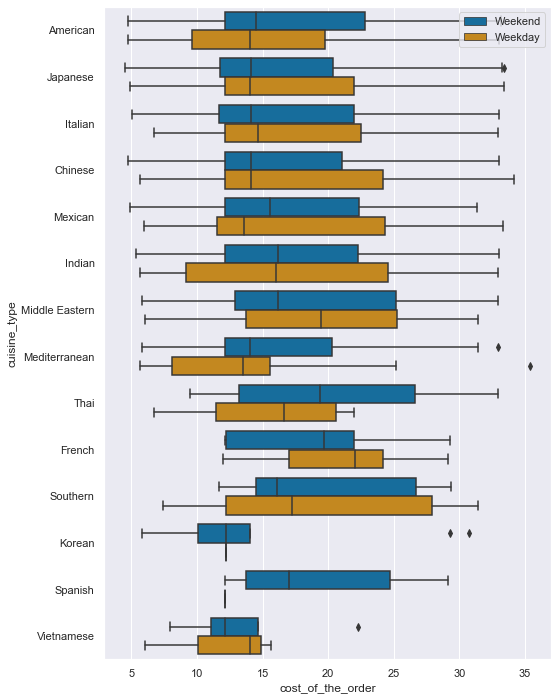

```python
plt.figure(figsize=(8, 12))
sns.boxplot(data = df,
            x = 'cost_of_the_order',
            y = 'cuisine_type',
            hue = 'day_of_the_week',
            palette = 'colorblind',
            order = df.cuisine_type.value_counts().index
           )
plt.legend(loc=1)
plt.show()
```

#### Prep time vs cuisine and weekday

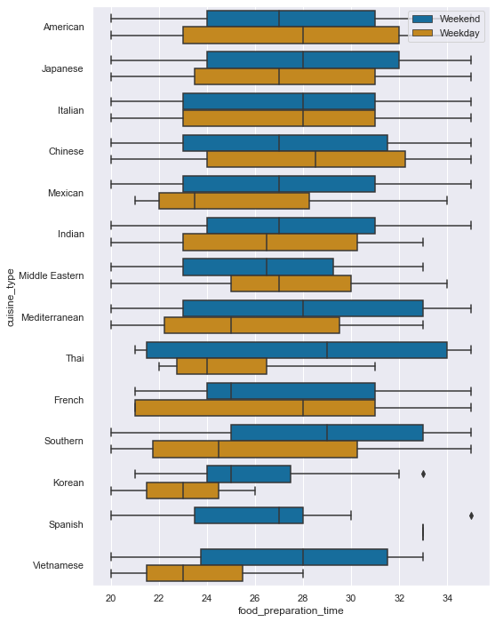

```python
plt.figure(figsize=(8, 12))
sns.boxplot(data = df,
            x = 'food_preparation_time',
            y = 'cuisine_type',
            hue = 'day_of_the_week',
            palette = 'colorblind',
            order = df.cuisine_type.value_counts().index
           )
plt.legend(loc=1)
plt.show()
```

#### Delivery time vs cuisine and weekday

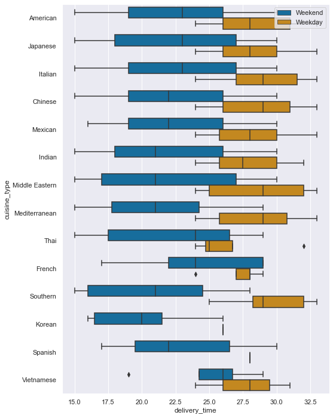

```python
plt.figure(figsize=(8, 12))
sns.boxplot(data = df,
            x = 'delivery_time',
            y = 'cuisine_type',
            hue = 'day_of_the_week',
            palette = 'colorblind',
            order = df.cuisine_type.value_counts().index
           )
plt.legend(loc=1)
plt.show()
```

These visualizations didn't add substantive additional insights. The difference between weekday and weekend in delivery times was already discovered, and the difference between cuisines didn't need to be classified by day of the week.